# Lab - Sistemas

*Processamento Digital de Sinais - UFPR - Prof. Eduardo Parente Ribeiro*

Nesta tarefa voce deve implementar sistemas discretos. Para tanto crie uma função que implemente uma equação que forneça uma saída y (*array*) a partir do sinal discreto de entrada x (*array*).

Criar uma função para cada sistema.

Teste o sistema com a sequência $x = \{0, 0, 0, 1, 2, 5, 3, 0, 0\}$, onde o primeiro valor corresponde a $n=0$. O *array* de saída pode ter tamanho diferente do *array* de entrada. Plotar tanto a entrada $x[n]$ quanto a saída $y[n]$ no mesmo eixo. Para não "esconder" o valor de $x[n]$, deslocar o valor de abcissa em 0.1 .

```python
from pylab import *
```

Exemplo de sistema que atrasa N unidades:  
$y[n]= T\{x[n]\}=x[n-N]$

```python
def sistema_Ex(x):
   y=concatenate((zeros(2),x))
   return y
```

para verificar o resultado use:

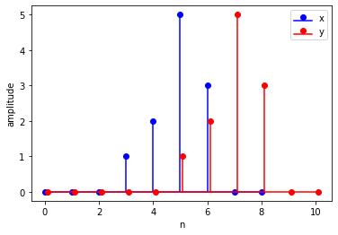

```python
n=arange(9)
x=array([0, 0, 0, 1, 2, 5, 3, 0, 0]);
# realiza deslocamento de N=2 unidades
y=sistema_Ex(x)
ny=arange(len(y))
stem(n,x,linefmt='b-',markerfmt='bo',basefmt='b',label='x')
# plota a saida deslocada de 0.1 para "enxergar" o valor
stem(ny+0.1,y,linefmt='r-',markerfmt='ro',basefmt='r',label='y')
xlabel('n')
ylabel('amplitude')
legend()
show()
```

1. Implemente e teste os seguintes sistemas:

a) atrasa a entrada em três unidades  
$y[n]= T\{x[n]\} = x[n-3]$

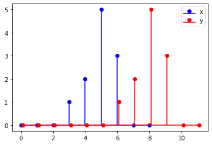

b) a saída corresponde ao valor quadrado da entrada.  
$y[n]= T\{x[n]\} = x[n]^2$

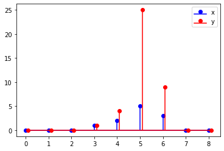

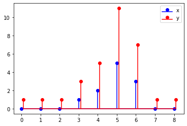

d) a saída corresponde a uma combinação linear da entrada multiplicada por 2 mais a entrada deslocada de 1 unidade multiplicada por 3.  
$y[n]= T\{x[n]\} = 2x[n] + 3x[n-1]$

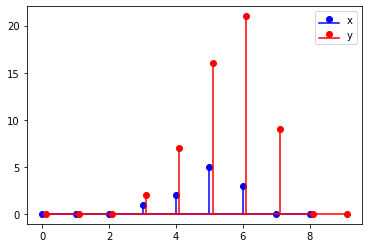

e) Média-móvel: Cada valor da saída seja a média aritmética do valor de entrada e suas 2 posições anteriores.  
$y[n]= T\{x[n]\} = \frac{1}{3}\sum_{k=n-2}^{n}{x[k]}$

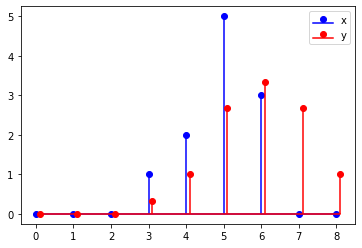

f) Acumulador. A saída corresponde a acumulação (soma) dos valores da entrada até o presente momento.  
$y[n]= T\{x[n]\} = \sum_{k=-\infty}^{n}{x[k]}$

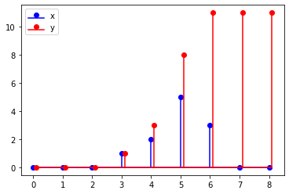

2. Classifique os sistemas anteriores dizendo se são:  
   I) linear ou não linear  
   II) com memória ou sem memória  
   III) invariante ao deslocamento ou variante ao deslocamento  
   IV) causal ou não causal  
   V) estável ou não estável

a) a) atrasa a entrada em três unidades  
$y[n]= T\{x[n]\} = x[n-3]$

b) a saída corresponde ao valor quadrático da entrada.  
$y[n]= T\{x[n]\} = x[n]^2$

c) a saída corresponde ao dobro da entrada somada ao valor 1.  
$y[n]= T\{x[n]\} = 2x[n]+1$

d) a saída corresponde a uma combinação linear da entrada multiplicada por 2 mais a entrada deslocada de 1 unidade multiplicada por 3.  
$y[n]= T\{x[n]\} = 2x[n]+3x[n-1]$

e) Média-móvel: Cada valor da saída seja a média aritmética do valor de entrada e suas 2 posições anteriores.  
$y[n]= T\{x[n]\} = \frac{1}{3}\sum_{k=n-2}^{n}{x[k]}$

f) Acumulador. A saída corresponde a acumulação (soma) dos valores da entrada até o presente momento.  
$y[n]= T\{x[n]\} = \sum_{k=-\infty}^{n}{x[k]}$